# Cluster Analysis

#### K-means - result for connected data

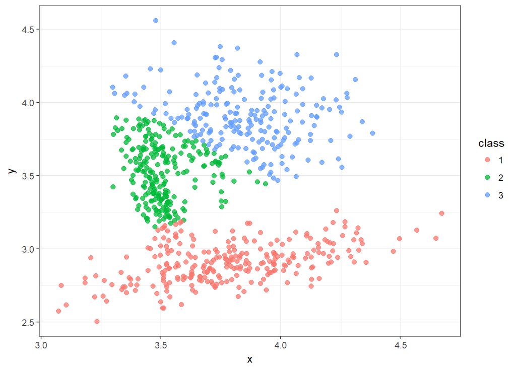

```r
km_res <- kmeans(datas_2, 3)

data_all[, class := as.factor(km_res$cluster)]

ggplot(data_all, aes(x, y, color = class)) +
  geom_point(alpha = 0.75, size = 2) +
  theme_bw()
```

#### Gaussian model-based clustering result

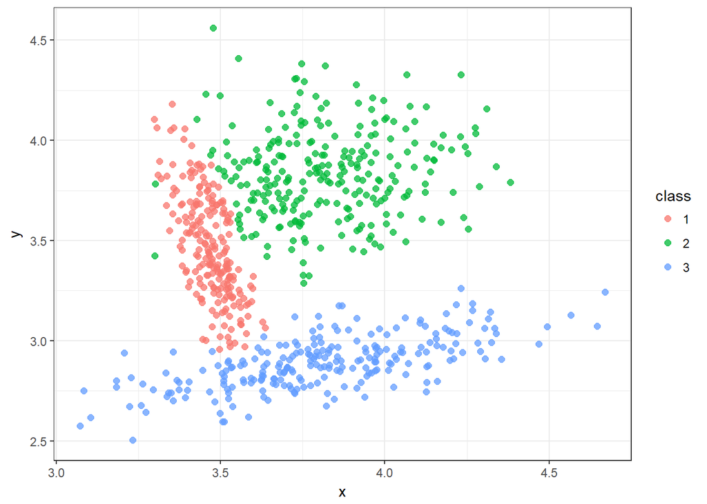

```r
m_res <- Mclust(datas_2, G = 3, modelNames = "VVV")

data_all[, class := as.factor(m_res$classification)]

ggplot(data_all, aes(x, y, color = class)) +
  geom_point(alpha = 0.75, size = 2) +
  theme_bw()
```

Almost perfect due to normality of data.

#### Spectral clustering result

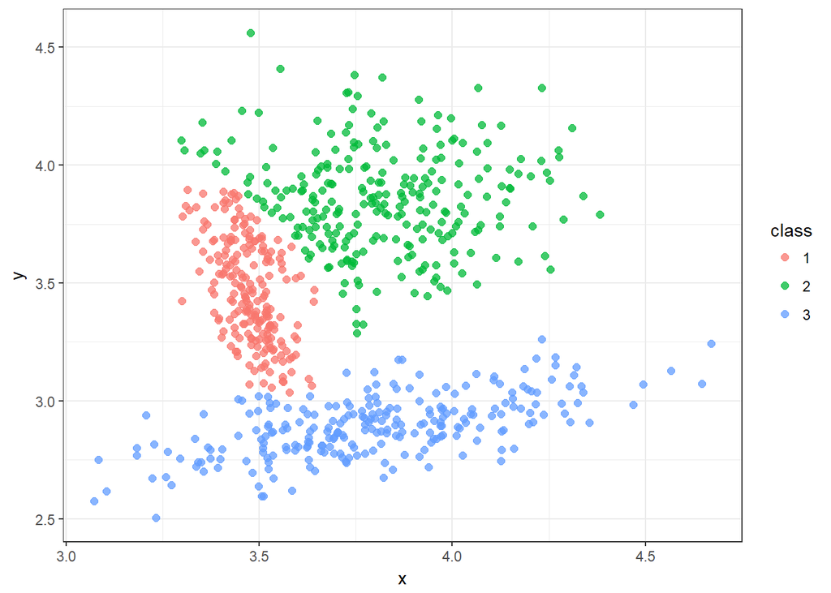

```r
res <- specc(data.matrix(datas_2[, .(x, y)]), centers = 3)

data_all[, class := as.factor(res)]

ggplot(data_all, aes(x, y, color = class)) +
  geom_point(alpha = 0.75, size = 2) +
  theme_bw()
```

Very nice result!

### Other types of clustering methods

- Grid-based
- Subspace clustering
- Multi-view clustering
- Based on artificial neural networks (e.g. SOM)
- Consensus (ensemble) clustering
- Data stream(s) clustering
- etc.

## Conclusions

- We have many types of clustering methods,
- Different datasets needs different clustering methods,
- Automatic determination of a number of clusters can be tricky,
- Real datasets are usually connected - density-based methods can fail,
- Outliers (anomalies) can significantly influence clustering results - solution is to preprocess the data,
- Some methods are not suited for large datasets - model-based or spectral,